# VSTE - Comparing Methods Visualization

Bridget Hegarty, James Riddell

07-22-2022

This Rmarkdown file assesses the output of CheckV, DeepVirFinder, Kaiju, VIBRANT, VirSorter, and VirSorter2 on multiple training sets of microbial DNA, primarily from NCBI. Created from fungal, viral, bacterial, archeael, protist, and plasmid DNA sequences

Please reach out to James Riddell (riddell.26@buckeyemail.osu.edu) or Bridget Hegarty (beh53@case.edu) regarding any issues, or open an issue on github.

```r
library(ggplot2)
library(plyr)
library(reshape2)
library(viridis)
library(tidyr)
library(dplyr)
library(readr)
library(data.table)
library("stringr")
```

Import the file that combines the results from each of the tools from running “combining_tool_output.Rmd”:

```r
viruses <- read_tsv("../IntermediaryFiles/viral_tools_combined.tsv")
```

You can decide which combination is appropriate for them and only need use the tools appropriate for your data.

```r
viruses$kaiju_match_ratio <- viruses$len/viruses$checkv_length
```

```r
getting_viral_set_1 <- function(input_seqs,
                                include_vibrant=FALSE,
                                include_virsorter2=FALSE,
                                include_deepvirfinder=FALSE,
                                include_tuning_viral=FALSE,
                                tv_1=T, tv_2=T, tv_3=T, tv_4=T, tv_5=T,
                                include_tuning_not_viral=FALSE,
                                ntv_1=T, ntv_2=T, ntv_3=T, ntv_4=T, ntv_5=F, ntv_6=T,
                                include_virsorter=FALSE) {

  keep_score <- rep(0, nrow(input_seqs))

  if (include_vibrant) {
    keep_score[input_seqs$vibrant_quality=="high quality draft"] <- keep_score[input_seqs$vibrant_quality=="high quality draft"] + 1
    keep_score[input_seqs$vibrant_quality=="medium quality draft"] <- keep_score[input_seqs$vibrant_quality=="medium quality draft"] + 1
    keep_score[input_seqs$vibrant_quality=="low quality draft" & input_seqs$provirus] <- keep_score[input_seqs$vibrant_quality=="low quality draft" & input_seqs$provirus] + 0.5
  }

  if (include_virsorter2) {
    keep_score[input_seqs$max_score>=0.50] <- keep_score[input_seqs$max_score>=0.50] + 0.5
    keep_score[input_seqs$max_score>=0.95] <- keep_score[input_seqs$max_score>=0.95] + 0.5
  }

  if (include_virsorter) {
    keep_score[input_seqs$category==1] <- keep_score[input_seqs$category==1] + 1
    keep_score[input_seqs$category==2] <- keep_score[input_seqs$category==2] + 0.5
    keep_score[input_seqs$category==3] <- keep_score[input_seqs$category==3] + 0.5
    keep_score[input_seqs$category==4] <- keep_score[input_seqs$category==4] + 1
    keep_score[input_seqs$category==5] <- keep_score[input_seqs$category==5] + 0.5
    keep_score[input_seqs$category==6] <- keep_score[input_seqs$category==6] + 0.5
  }

  if (include_deepvirfinder) {
     # add if DVF calls viral
    keep_score[(input_seqs$score>=0.9 & input_seqs$pvalue<=0.05) & input_seqs$checkv_length<20000] <- keep_score[(input_seqs$score>=0.9 & input_seqs$pvalue<=0.05) & input_seqs$checkv_length<20000] + 0.5
    keep_score[(input_seqs$score>=0.7 & input_seqs$pvalue<=0.05) & input_seqs$checkv_length<20000] <- keep_score[(input_seqs$score>=0.7 & input_seqs$pvalue<=0.05) & input_seqs$checkv_length<20000] + 0.5
  }

  if (include_tuning_viral) {
    keep_score <- tuning_viral(current_score=keep_score,
                               ins=input_seqs,
                         include_tv_1=tv_1,
                         include_tv_2=tv_2,
                         include_tv_3=tv_3,
                         include_tv_4=tv_4,
                         include_tv_5=tv_5)
  }

  if (include_tuning_not_viral) {
    # tuning removal
    keep_score <- tuning_not_viral(current_score=keep_score,
                               ins=input_seqs,
                         include_tv_1=ntv_1,
                         include_tv_2=ntv_2,
                         include_tv_3=ntv_3,
                         include_tv_4=ntv_4,
                         include_tv_5=ntv_5,
                         include_tv_6=ntv_6)

  }

  return(keep_score)

}

tuning_viral <- function(current_score, ins,
                         include_tv_1=T,
                         include_tv_2=T,
                         include_tv_3=T,
                         include_tv_4=T,
                         include_tv_5=T) {
    # tuning addition
  if (include_tv_1) {
    current_score[ins$hallmark>2] <- current_score[ins$hallmark>2] + 1
  }
  if (include_tv_2) {
    current_score[ins$Kaiju_Viral=="Viruses" & ins$kaiju_match_ratio>=0.3] <- current_score[ins$Kaiju_Viral=="Viruses" & ins$kaiju_match_ratio>=0.3] + 1
  }
    #note: had tried pulling out this rule, but better recall without sacrificing precision with it in
    #note: having kaiju removal rule didn't help
  if (include_tv_3) {
    current_score[ins$percent_unknown>=75 & ins$checkv_length<50000] <- current_score[ins$percent_unknown>=75 & ins$checkv_length<50000] + 0.5
  }
  if (include_tv_4) {
    current_score[ins$viral>=50 | ins$percent_viral>=50] <- current_score[ins$viral>=50 | ins$percent_viral>=50] + 0.5
  }
  if (include_tv_5) {
    current_score[(ins$checkv_completeness>=75 | ins$vibrant_quality=="complete circular") & (ins$viral>=50 | ins$percent_viral>=50)] <- current_score[(ins$checkv_completeness>=75 | ins$vibrant_quality=="complete circular") & (ins$viral>=50 | ins$percent_viral>=50)] + 0.5
  }

  return(current_score)
}

tuning_not_viral <- function(current_score, ins,
                         include_tv_1=T,
                         include_tv_2=T,
                         include_tv_3=T,
                         include_tv_4=T,
                         include_tv_5=F,
                         include_tv_6=F) {
    # tuning addition
  if (include_tv_1) {
    current_score[(ins$checkv_host_genes>50) & !ins$provirus] <- 0
  }
  if (include_tv_2) {
    current_score[ins$checkv_viral_genes==0 & ins$checkv_host_genes>=1] <- current_score[ins$checkv_viral_genes==0 & ins$checkv_host_genes>=1] - 1
  }
  if (include_tv_3) {
    current_score[((ins$checkv_viral_genes*3) <= ins$checkv_host_genes) & !ins$provirus] <- current_score[((ins$checkv_viral_genes*3) <= ins$checkv_host_genes) & !ins$provirus] - 1
  }
  if (include_tv_4) {
    current_score[ins$checkv_length>500000 & ins$hallmark<=1] <- 0
  }
  #if (include_tv_5) {
  #  current_score[(ins$checkv_completeness<=75) & ins$checkv_length<=5000] <- current_score[(ins$checkv_completeness<=75) & ins$checkv_length<=5000] - 0.5
  #}

  if (include_tv_6) {
    # remove if DVF calls it not viral
    current_score[ins$score<=0.7 & ins$pvalue<=0.05] <- current_score[ins$score<=0.7 & ins$pvalue<=0.05] - 1
  }

  return(current_score)
}
```

# Comparing all of the tool methods

```r
combos_list <- data.frame(toolcombo=rep(0, 64),
                          tune_not_viral=rep(0, 64),
                          DVF=rep(0, 64),
                          tune_viral=rep(0, 64),
                          VIBRANT=rep(0, 64),
                          VS=rep(0, 64),
                          VS2=rep(0, 64))
p <- 1

for (i in c(0,1)){
  for (j in c(0,1)){
    for (k in c(0,1)){
      for (l in c(0,1)){
        for (m in c(0,1)){
          for (n in c(0,1)){
            combos_list$toolcombo[p] <- paste(i,j,k,l,m,n)
            combos_list$toolcombo2[p] <- paste(if(i){"tnv"}else{"0"},if(j){"DVF"}else{"0"},
                                               if(k){"tv"}else{"0"},if(l){"VB"}else{"0"},
                                               if(m){"VS"}else{"0"},if(n){"VS2"}else{"0"})
            combos_list$tune_not_viral[p] <- i
            combos_list$DVF[p] <- j
            combos_list$tune_viral[p] <- k
            combos_list$VIBRANT[p] <- l
            combos_list$VS[p] <- m
            combos_list$VS2[p] <- n
            p <- p+1
          }
        }
      }
    }
  }
}

combos_list <- combos_list[-1,]
```

```r
viral_scores <- matrix(data=0, nrow=nrow(viruses), ncol=nrow(combos_list))
```

```
There were 50 or more warnings (use warnings() to see the first 50)
```

```r
num_viruses <- data.frame(toolcombo=rep(0, nrow(combos_list)),
                          num_viruses=rep(0, nrow(combos_list)))
for (i in 1:nrow(combos_list)) {
  viral_scores[,i] <- getting_viral_set_1(viruses, include_vibrant = combos_list$VIBRANT[i],
                                            include_virsorter = combos_list$VS[i],
                                            include_virsorter2 = combos_list$VS2[i],
                                            include_tuning_viral = combos_list$tune_viral[i],
                                            include_tuning_not_viral = combos_list$tune_not_viral[i],
                                            include_deepvirfinder = combos_list$DVF[i])

  if (max(viral_scores[,i])<=0) {
    num_viruses$num_viruses[i] <- 0
  }
  else {
    num_viruses$num_viruses[i] <- table(viral_scores[,i]>=1)[[2]]
  }
  num_viruses$toolcombo[i] <- combos_list$toolcombo[i]

  num_viruses$toolcombo2[i] <- combos_list$toolcombo2[i]
}
num_viruses$numtools <- str_count(num_viruses$toolcombo, "1")
num_viruses <- num_viruses[order(num_viruses$num_viruses, decreasing=F),]
num_viruses$toolcombo <- factor(num_viruses$toolcombo, levels = unique(num_viruses$toolcombo))
num_viruses$toolcombo2 <- factor(num_viruses$toolcombo2, levels = unique(num_viruses$toolcombo2))
num_viruses$numtools <- as.factor(num_viruses$numtools)
```

```r
dim(viral_scores)
```

```
[1] 96291    63
```

```r
pal <- ggthemes::tableau_color_pal(palette="Tableau 10", type="regular")

viruses_1 <- viruses[viruses$Index=="1",]

ann_col = data.frame(
    tnv = combos_list$tune_not_viral,
    tv = combos_list$tune_viral,
    dvf = combos_list$DVF,
    vb = combos_list$VIBRANT,
    vs = combos_list$VS,
    vs2 = combos_list$VS2
)

ann_row = data.frame(
    seqtype = viruses_1$seqtype
)

ann_colors = list(
  tnv = c("black", pal(6)[1]),
  tv = c("black", pal(6)[3]),
  dvf = c("black", pal(6)[2]),
  vb = c("black", pal(6)[4]),
  vs = c("black", pal(6)[5]),
  vs2 = c("black", pal(6)[6]),
  seqtype = c("archaea"=pal(6)[1], "bacteria"=pal(6)[2], "fungi"=pal(6)[3],
              "plasmid"=pal(6)[4], "protist"=pal(6)[5], "virus"=pal(6)[6])
)

rownames(ann_col) <- combos_list$toolcombo
rownames(ann_row) <- viruses_1$contig

viral_scores_1 <- viral_scores[viruses$Index=="1",]

colnames(viral_scores_1) <- combos_list$toolcombo
rownames(viral_scores_1) <- viruses_1$contig
```

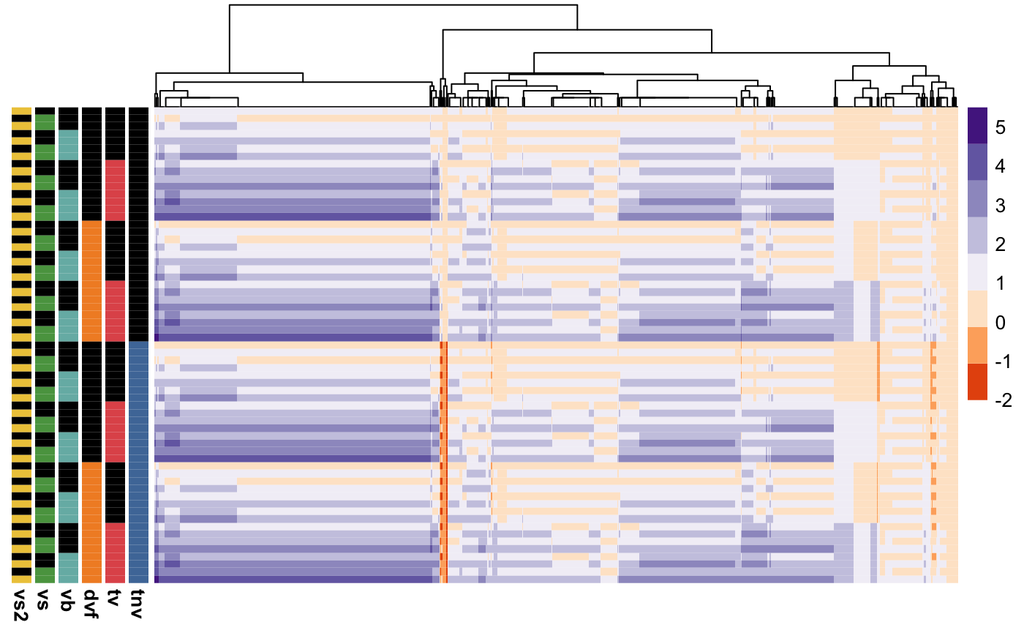

```r
pheatmap::pheatmap(t(viral_scores_1[(viruses_1$seqtype=="virus"),]),
                  annotation_row = ann_col,
                  annotation_colors = ann_colors,
                  #border_color = "black",
                  color = c(rev(RColorBrewer::brewer.pal(3,"Oranges")),
                            RColorBrewer::brewer.pal(5,"Purples")
                            ),
                  show_rownames = F,
                  show_colnames = F,
                  annotation_legend = F,
                  cluster_rows=F#,
                 # filename = "../IntermediaryFiles/pheatmap_virus_set_1_viral_scores.png"
                  )
```

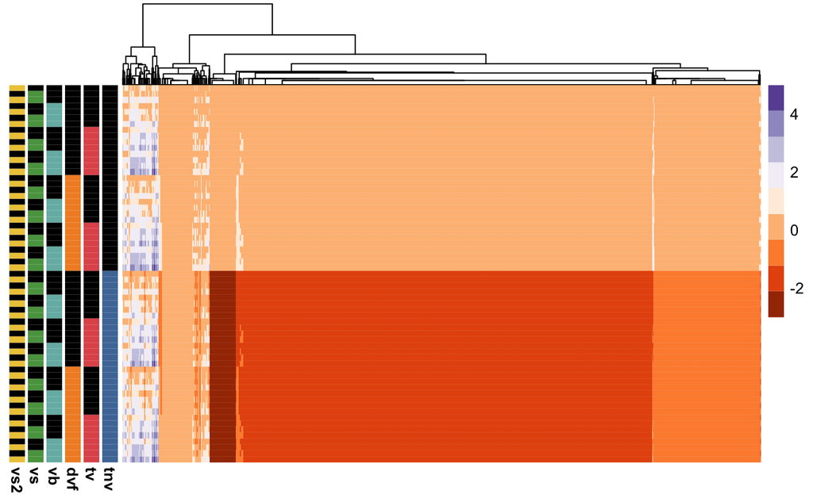

```r
pheatmap::pheatmap(t(viral_scores_1[(viruses_1$seqtype=="bacteria"),]),
                  annotation_row = ann_col,
                  annotation_colors = ann_colors,
                  #border_color = "black",
                  color = c(rev(RColorBrewer::brewer.pal(5,"Oranges")),
                            RColorBrewer::brewer.pal(4,"Purples")
                            ),
                  show_rownames = F,
                  show_colnames = F,
                  annotation_legend = F,
                  cluster_rows=F#,
                 # filename = "../IntermediaryFiles/pheatmap_virus_set_1_viral_scores.png"
                  )
```

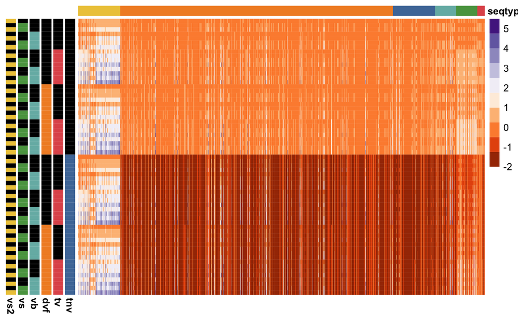

```r
pheatmap::pheatmap(t(viral_scores_1),
                  annotation_col = ann_row,
                  annotation_row = ann_col,
                  annotation_colors = ann_colors,
                  #border_color = "black",
                  color = c(rev(RColorBrewer::brewer.pal(5,"Oranges")),
                            RColorBrewer::brewer.pal(5,"Purples")
                            ),
                  show_rownames = F,
                  show_colnames = F,
                  annotation_legend = F,
                  cluster_rows = F,
                  cluster_cols = F#,
                 # filename = "../IntermediaryFiles/pheatmap_virus_set_1_viral_scores.png"
                  )
```

##matrix of number in agreement between tools ### number predicted together

```r
num_high_viruses <- matrix(data=NA, nrow=63, ncol=63)
prop_high_viruses <- matrix(data=NA, nrow=63, ncol=63)

for (i in 1:63) {
  for (j in 1:63) {
    num_high_viruses[i,j] <- sum(viral_scores[,i]>=1 & viral_scores[,j]>=1)

    prop_high_viruses[i,j] <- sum(viral_scores[,i]>=1 & viral_scores[,j]>=1)
    prop_high_viruses[i,j] <- prop_high_viruses[i,j]/sum(viral_scores[,i]>=1 | viral_scores[,j]>=1)
  }
}

rownames(num_high_viruses) <- combos_list$toolcombo
colnames(num_high_viruses) <- combos_list$toolcombo

rownames(prop_high_viruses) <- combos_list$toolcombo
colnames(prop_high_viruses) <- combos_list$toolcombo
```

```r
pal <- ggthemes::tableau_color_pal(palette="Tableau 10", type="regular")

ann_col = data.frame(
    tnv = combos_list$tune_not_viral,
    tv = combos_list$tune_viral,
    dvf = combos_list$DVF,
    vb = combos_list$VIBRANT,
    vs = combos_list$VS,
    vs2 = combos_list$VS2,
    num_vir = colSums(viral_scores>=1)+1
)

ann_colors = list(
  num_vir=magma(100),
  tnv = c("black", pal(6)[1]),
  tv = c("black", pal(6)[3]),
  dvf = c("black", pal(6)[2]),
  vb = c("black", pal(6)[4]),
  vs = c("black", pal(6)[5]),
  vs2 = c("black", pal(6)[6])
)

rownames(ann_col) <- combos_list$toolcombo

pheatmap::pheatmap(num_high_viruses,
                  annotation_row = ann_col,
                  annotation_colors = ann_colors,
                  border_color = "black",
                  color = magma(100),
                  cutree_rows = 4,
                  cutree_cols = 4,
                  show_rownames = F,
                  filename = "../IntermediaryFiles/pheatmap_num_viruses_in_common.png",
                  annotation_legend = F)
```

```r
pal <- ggthemes::tableau_color_pal(palette="Tableau 10", type="regular")

ann_col = data.frame(
    tnv = combos_list$tune_not_viral,
    tv = combos_list$tune_viral,
    dvf = combos_list$DVF,
    vb = combos_list$VIBRANT,
    vs = combos_list$VS,
    vs2 = combos_list$VS2,
    num_vir = colSums(viral_scores>=1)+1
)

ann_colors = list(
  num_vir=magma(100),
  tnv = c("black", pal(6)[1]),
  tv = c("black", pal(6)[3]),
  dvf = c("black", pal(6)[2]),
  vb = c("black", pal(6)[4]),
  vs = c("black", pal(6)[5]),
  vs2 = c("black", pal(6)[6])
)

rownames(ann_col) <- combos_list$toolcombo

pheatmap::pheatmap(prop_high_viruses,
                  annotation_row = ann_col,
                  annotation_colors = ann_colors,
                  border_color = "black",
                  color = viridis(100),
                  cutree_rows = 4,
                  cutree_cols = 4,
                  show_rownames = F,
                  filename = "../IntermediaryFiles/pheatmap_prop_viruses_in_common.png",
                  annotation_legend = F)
```

# overlap in proportion of contigs for tool sets

get number of tools and number of rules for each combination

```r
ann_col$numrules <- rowSums(ann_col[,1:6])
```

[output not shown]

```r
ann_col$numtools <- ann_col$numrules

for (i in 1:nrow(ann_col)) {
  if (ann_col$tv[i]==1) {
    ann_col$numtools[i] <- ann_col$numtools[i] + 3
  }

  if (ann_col$tnv[i]==1) {
    ann_col$numtools[i] <- ann_col$numtools[i] + 5
  }
}

ann_col$numtools[ann_col$numtools>6] <- 6

ann_col$tool <- rownames(ann_col)
```

```r
prop_high_viruses_long <- as.data.frame(prop_high_viruses)
prop_high_viruses_long$tool <- combos_list$toolcombo

prop_high_viruses_long <- as.data.frame(prop_high_viruses_long) %>%
  pivot_longer(!tool,
               values_to="proportion",
               names_to="tool2") %>%
  inner_join(ann_col, by=c("tool"))
```

| tool | tool2 | proportion | tnv | tv | dvf | vb | vs | vs2 | num_vir | numrules | numtools |
| --- | --- | --- | --- | --- | --- | --- | --- | --- | --- | --- | --- |
| 0 0 0 0 0 1 | 0 0 0 0 0 1 | 1.0000000 | 0 | 0 | 0 | 0 | 0 | 1 | 11755 | 1 | 1 |
| 0 0 0 0 0 1 | 0 0 0 0 1 0 | 0.1328541 | 0 | 0 | 0 | 0 | 0 | 1 | 11755 | 1 | 1 |
| 0 0 0 0 0 1 | 0 0 0 0 1 1 | 0.7641896 | 0 | 0 | 0 | 0 | 0 | 1 | 11755 | 1 | 1 |
| 0 0 0 0 0 1 | 0 0 0 1 0 0 | 0.4156260 | 0 | 0 | 0 | 0 | 0 | 1 | 11755 | 1 | 1 |
| 0 0 0 0 0 1 | 0 0 0 1 0 1 | 0.8576432 | 0 | 0 | 0 | 0 | 0 | 1 | 11755 | 1 | 1 |
| 0 0 0 0 0 1 | 0 0 0 1 1 0 | 0.4307735 | 0 | 0 | 0 | 0 | 0 | 1 | 11755 | 1 | 1 |

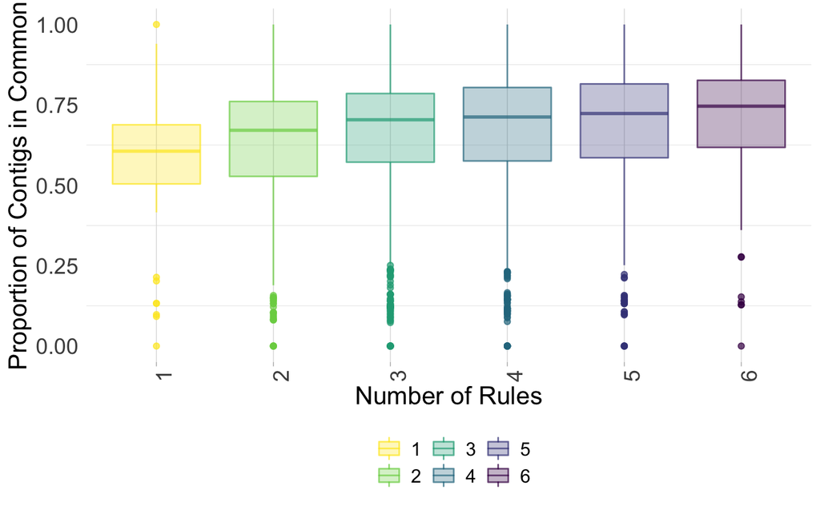

```r
ggplot(prop_high_viruses_long[prop_high_viruses_long$vs2==1,], aes(x=as.factor(numrules), y=proportion,
                                  color=as.factor(numrules), fill=as.factor(numrules))) +
  geom_boxplot() +
  #geom_point() +
  theme_light() +
  theme(
    panel.grid.major.y = element_blank(),
    panel.border = element_blank(),
    axis.ticks.y = element_blank(),
    legend.position = "bottom",
    axis.text.y=element_text(size=14),
    axis.text.x=element_text(size=14, angle = 90),
    legend.text=element_text(size=12),
    axis.title=element_text(size=16),
  ) +
  xlab("Number of Rules") +
  ylab("Proportion of Contigs in Common") +
  scale_fill_manual(name="",
                     values = alpha(rev(viridis(6)), 0.3)) +
  scale_color_manual(name="",
                     values = alpha(rev(viridis(6)), 0.7))
```

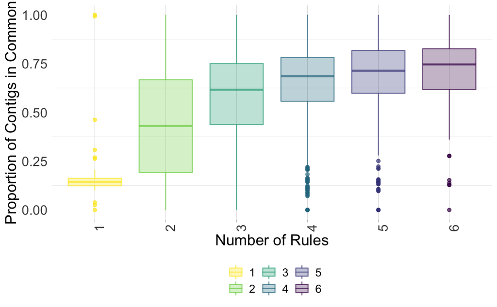

```r
ggplot(prop_high_viruses_long[prop_high_viruses_long$vs==1,], aes(x=as.factor(numrules), y=proportion,
                                  color=as.factor(numrules), fill=as.factor(numrules))) +
  geom_boxplot() +
  #geom_point() +
  theme_light() +
  theme(
    panel.grid.major.y = element_blank(),
    panel.border = element_blank(),
    axis.ticks.y = element_blank(),
    legend.position = "bottom",
    axis.text.y=element_text(size=14),
    axis.text.x=element_text(size=14, angle = 90),
    legend.text=element_text(size=12),
    axis.title=element_text(size=16),
  ) +
  xlab("Number of Rules") +
  ylab("Proportion of Contigs in Common") +
  scale_fill_manual(name="",
                     values = alpha(rev(viridis(6)), 0.3)) +
  scale_color_manual(name="",
                     values = alpha(rev(viridis(6)), 0.7))
```

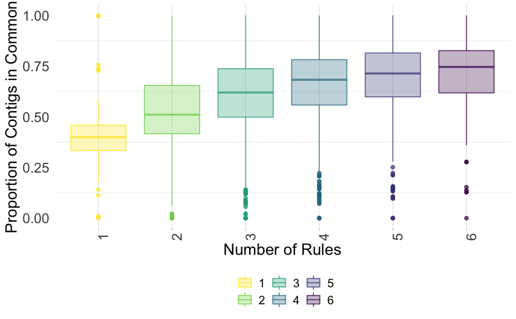

```r
ggplot(prop_high_viruses_long[prop_high_viruses_long$vb==1,], aes(x=as.factor(numrules), y=proportion,
                                  color=as.factor(numrules), fill=as.factor(numrules))) +
  geom_boxplot() +
  #geom_point() +
  theme_light() +
  theme(
    panel.grid.major.y = element_blank(),
    panel.border = element_blank(),
    axis.ticks.y = element_blank(),
    legend.position = "bottom",
    axis.text.y=element_text(size=14),
    axis.text.x=element_text(size=14, angle = 90),
    legend.text=element_text(size=12),
    axis.title=element_text(size=16),
  ) +
  xlab("Number of Rules") +
  ylab("Proportion of Contigs in Common") +
  scale_fill_manual(name="",
                     values = alpha(rev(viridis(6)), 0.3)) +
  scale_color_manual(name="",
                     values = alpha(rev(viridis(6)), 0.7))
```

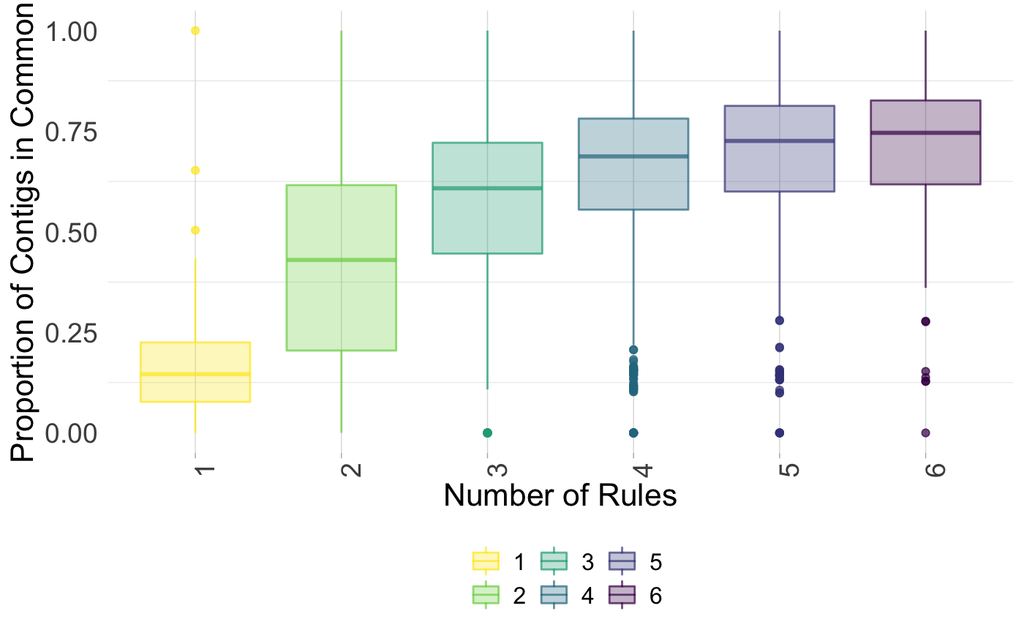

```r
ggplot(prop_high_viruses_long[prop_high_viruses_long$dvf==1,], aes(x=as.factor(numrules), y=proportion,
                                  color=as.factor(numrules), fill=as.factor(numrules))) +
  geom_boxplot() +
  #geom_point() +
  theme_light() +
  theme(
    panel.grid.major.y = element_blank(),
    panel.border = element_blank(),
    axis.ticks.y = element_blank(),
    legend.position = "bottom",
    axis.text.y=element_text(size=14),
    axis.text.x=element_text(size=14, angle = 90),
    legend.text=element_text(size=12),
    axis.title=element_text(size=16),
  ) +
  xlab("Number of Rules") +
  ylab("Proportion of Contigs in Common") +
  scale_fill_manual(name="",
                     values = alpha(rev(viridis(6)), 0.3)) +
  scale_color_manual(name="",
                     values = alpha(rev(viridis(6)), 0.7))
```

```r
table(prop_high_viruses_long$numrules[prop_high_viruses_long$dvf==1])
```

```
  1   2   3   4   5   6
 63 315 630 630 315  63
```

[output not shown]

```r
ggplot(prop_high_viruses_long[prop_high_viruses_long$vs2==1,], aes(x=as.factor(numtools), y=proportion,
```

[output not shown]

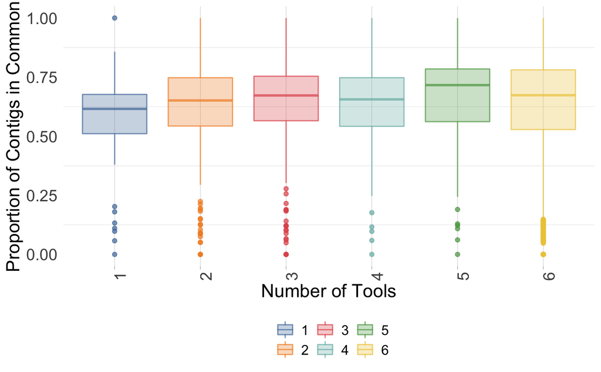

```r
                                  color=as.factor(numtools), fill=as.factor(numtools))) +
  geom_boxplot() +
  #geom_point() +
  theme_light() +
  theme(
    panel.grid.major.y = element_blank(),
    panel.border = element_blank(),
    axis.ticks.y = element_blank(),
    legend.position = "bottom",
    axis.text.y=element_text(size=14),
    axis.text.x=element_text(size=14, angle = 90),
    legend.text=element_text(size=12),
    axis.title=element_text(size=16),
  ) +
  xlab("Number of Tools") +
  ylab("Proportion of Contigs in Common") +
  scale_fill_manual(name="",
                     values = alpha(pal(6), 0.3)) +
  scale_color_manual(name="",
                     values = alpha(pal(6), 0.7))
```

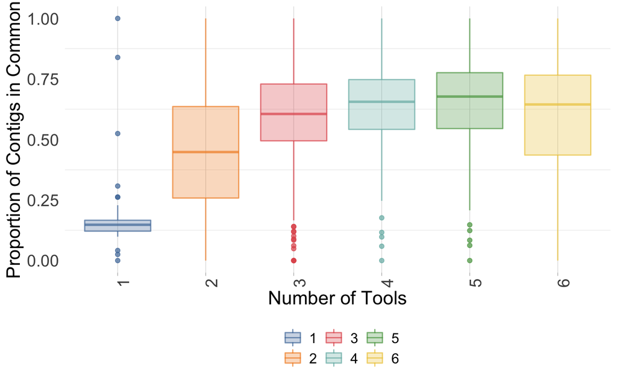

```r
ggplot(prop_high_viruses_long[prop_high_viruses_long$vs==1,], aes(x=as.factor(numtools), y=proportion,
                                  color=as.factor(numtools), fill=as.factor(numtools))) +
  geom_boxplot() +
  #geom_point() +
  theme_light() +
  theme(
    panel.grid.major.y = element_blank(),
    panel.border = element_blank(),
    axis.ticks.y = element_blank(),
    legend.position = "bottom",
    axis.text.y=element_text(size=14),
    axis.text.x=element_text(size=14, angle = 90),
    legend.text=element_text(size=12),
    axis.title=element_text(size=16),
  ) +
  xlab("Number of Tools") +
  ylab("Proportion of Contigs in Common") +
  scale_fill_manual(name="",
                     values = alpha(pal(6), 0.3)) +
  scale_color_manual(name="",
                     values = alpha(pal(6), 0.7))
```

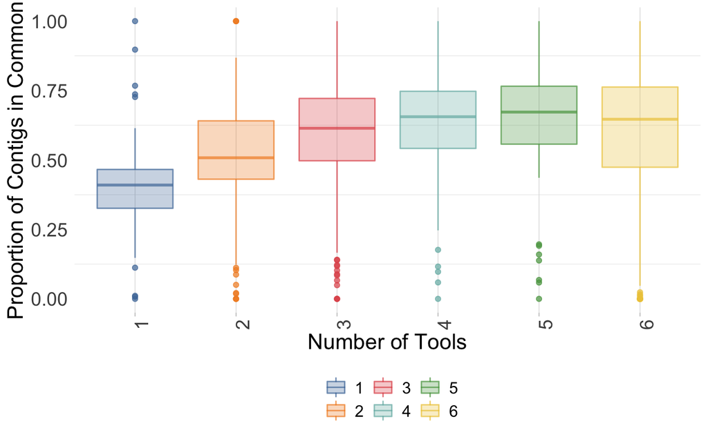

```r
ggplot(prop_high_viruses_long[prop_high_viruses_long$vb==1,], aes(x=as.factor(numtools), y=proportion,
                                  color=as.factor(numtools), fill=as.factor(numtools))) +
  geom_boxplot() +
  #geom_point() +
  theme_light() +
  theme(
    panel.grid.major.y = element_blank(),
    panel.border = element_blank(),
    axis.ticks.y = element_blank(),
    legend.position = "bottom",
    axis.text.y=element_text(size=14),
    axis.text.x=element_text(size=14, angle = 90),
    legend.text=element_text(size=12),
    axis.title=element_text(size=16),
  ) +
  xlab("Number of Tools") +
  ylab("Proportion of Contigs in Common") +
  scale_fill_manual(name="",
                     values = alpha(pal(6), 0.3)) +
  scale_color_manual(name="",
                     values = alpha(pal(6), 0.7))
```

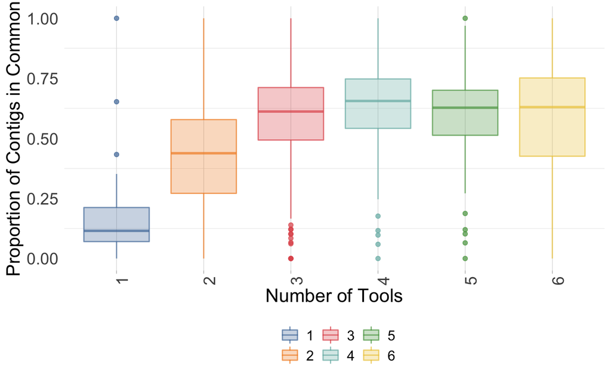

```r
ggplot(prop_high_viruses_long[prop_high_viruses_long$dvf==1,], aes(x=as.factor(numtools), y=proportion,
                                  color=as.factor(numtools), fill=as.factor(numtools))) +
  geom_boxplot() +
  #geom_point() +
  theme_light() +
  theme(
    panel.grid.major.y = element_blank(),
    panel.border = element_blank(),
    axis.ticks.y = element_blank(),
    legend.position = "bottom",
    axis.text.y=element_text(size=14),
    axis.text.x=element_text(size=14, angle = 90),
    legend.text=element_text(size=12),
    axis.title=element_text(size=16),
  ) +
  xlab("Number of Tools") +
  ylab("Proportion of Contigs in Common") +
  scale_fill_manual(name="",
                     values = alpha(pal(6), 0.3)) +
  scale_color_manual(name="",
                     values = alpha(pal(6), 0.7))
```

rather than tool against all others, ones against ones, twos against twos…

```r
prop_high_viruses_long$numtoolscommon <- as.factor(prop_high_viruses_long$numtoolscommon)
```

```r
ggplot(prop_high_viruses_long[prop_high_viruses_long$vs2==1,], aes(x=as.factor(numtoolscommon), y=proportion,
```

[output not shown]

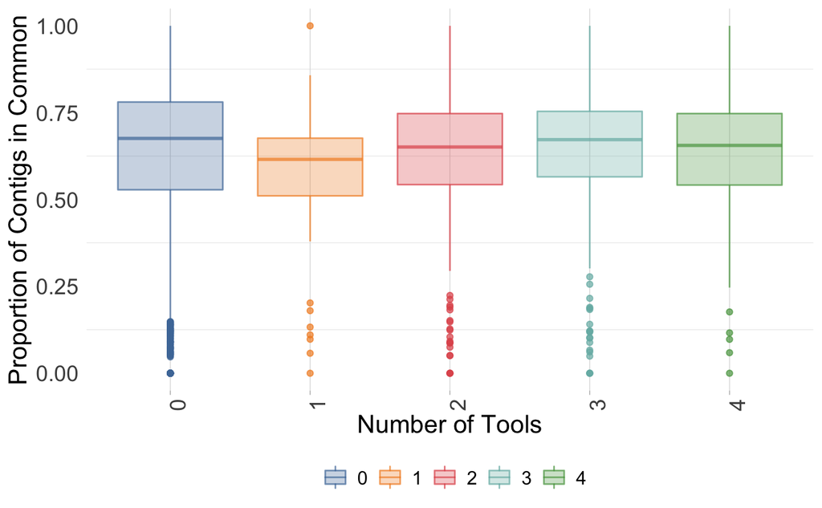

```r
                                  color=as.factor(numtoolscommon), fill=as.factor(numtoolscommon))) +
  geom_boxplot() +
  #geom_point() +
  theme_light() +
  theme(
    panel.grid.major.y = element_blank(),
    panel.border = element_blank(),
    axis.ticks.y = element_blank(),
    legend.position = "bottom",
    axis.text.y=element_text(size=14),
    axis.text.x=element_text(size=14, angle = 90),
    legend.text=element_text(size=12),
    axis.title=element_text(size=16),
  ) +
  xlab("Number of Tools") +
  ylab("Proportion of Contigs in Common") +
  scale_fill_manual(name="",
                     values = alpha(pal(6), 0.3)) +
  scale_color_manual(name="",
                     values = alpha(pal(6), 0.7))
```

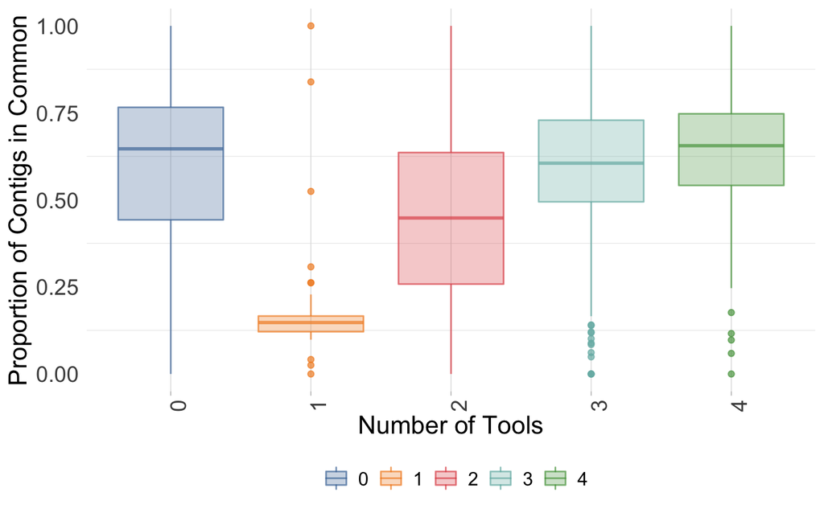

```r
ggplot(prop_high_viruses_long[prop_high_viruses_long$vs==1,], aes(x=as.factor(numtoolscommon), y=proportion,
                                  color=as.factor(numtoolscommon), fill=as.factor(numtoolscommon))) +
  geom_boxplot() +
  #geom_point() +
  theme_light() +
  theme(
    panel.grid.major.y = element_blank(),
    panel.border = element_blank(),
    axis.ticks.y = element_blank(),
    legend.position = "bottom",
    axis.text.y=element_text(size=14),
    axis.text.x=element_text(size=14, angle = 90),
    legend.text=element_text(size=12),
    axis.title=element_text(size=16),
  ) +
  xlab("Number of Tools") +
  ylab("Proportion of Contigs in Common") +
  scale_fill_manual(name="",
                     values = alpha(pal(6), 0.3)) +
  scale_color_manual(name="",
                     values = alpha(pal(6), 0.7))
```

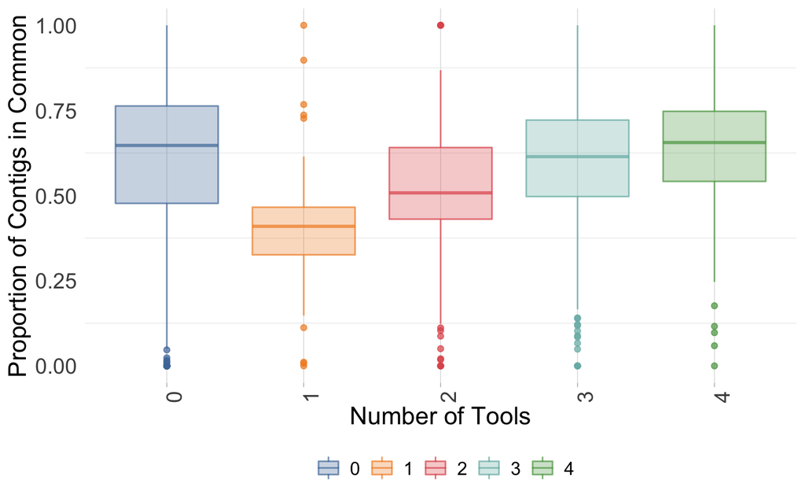

```r
ggplot(prop_high_viruses_long[prop_high_viruses_long$vb==1,], aes(x=as.factor(numtoolscommon), y=proportion,
                                  color=as.factor(numtoolscommon), fill=as.factor(numtoolscommon))) +
  geom_boxplot() +
  #geom_point() +
  theme_light() +
  theme(
    panel.grid.major.y = element_blank(),
    panel.border = element_blank(),
    axis.ticks.y = element_blank(),
    legend.position = "bottom",
    axis.text.y=element_text(size=14),
    axis.text.x=element_text(size=14, angle = 90),
    legend.text=element_text(size=12),
    axis.title=element_text(size=16),
  ) +
  xlab("Number of Tools") +
  ylab("Proportion of Contigs in Common") +
  scale_fill_manual(name="",
                     values = alpha(pal(6), 0.3)) +
  scale_color_manual(name="",
                     values = alpha(pal(6), 0.7))
```

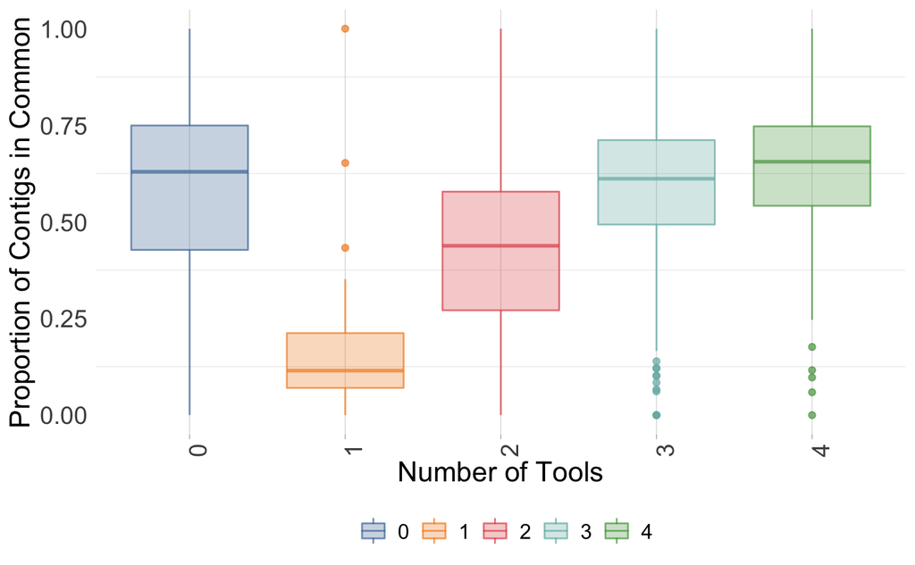

```r
ggplot(prop_high_viruses_long[prop_high_viruses_long$dvf==1,], aes(x=as.factor(numtoolscommon), y=proportion,
                                  color=as.factor(numtoolscommon), fill=as.factor(numtoolscommon))) +
  geom_boxplot() +
  #geom_point() +
  theme_light() +
  theme(
    panel.grid.major.y = element_blank(),
    panel.border = element_blank(),
    axis.ticks.y = element_blank(),
    legend.position = "bottom",
    axis.text.y=element_text(size=14),
    axis.text.x=element_text(size=14, angle = 90),
    legend.text=element_text(size=12),
    axis.title=element_text(size=16),
  ) +
  xlab("Number of Tools") +
  ylab("Proportion of Contigs in Common") +
  scale_fill_manual(name="",
                     values = alpha(pal(6), 0.3)) +
  scale_color_manual(name="",
                     values = alpha(pal(6), 0.7))
```

# distribution of proportion in common for each pair

```r
prop_high_viruses_long <- as.data.frame(prop_high_viruses)
prop_high_viruses_long$tool <- combos_list$toolcombo

prop_high_viruses_long <- as.data.frame(prop_high_viruses_long) %>%
  pivot_longer(!tool,
               values_to="proportion",
               names_to="tool2")

prop_high_viruses_long$binned_prop <- "0-10%"
prop_high_viruses_long$binned_prop[prop_high_viruses_long$proportion>=0.10] <- "10-50%"
prop_high_viruses_long$binned_prop[prop_high_viruses_long$proportion>=0.50] <- "50-90%"
prop_high_viruses_long$binned_prop[prop_high_viruses_long$proportion>=0.90] <- "90-100%"
```

```r
table(prop_high_viruses_long$binned_prop)
```

```
  0-10%  10-50%  50-90% 90-100%
    229    1052    2516     172
```

```r
prop_high_viruses_long$toolcombo <- paste(prop_high_viruses_long$tool,
                                          prop_high_viruses_long$tool2,
                                          sep="-")
prop_high_viruses_long$toolcombo <- gsub(" ", "", prop_high_viruses_long$toolcombo)
prop_high_viruses_long$toolcombo <- unique(prop_high_viruses_long$toolcombo)
```

```r
head(prop_high_viruses_long)
```

| tool | tool2 | proportion | binned_prop | toolcombo |
| --- | --- | --- | --- | --- |
| 0 0 0 0 0 1 | 0 0 0 0 0 1 | 1.0000000 | 90-100% | 000001-000001 |
| 0 0 0 0 0 1 | 0 0 0 0 1 0 | 0.1328541 | 10-50% | 000001-000010 |
| 0 0 0 0 0 1 | 0 0 0 0 1 1 | 0.7641896 | 50-90% | 000001-000011 |
| 0 0 0 0 0 1 | 0 0 0 1 0 0 | 0.4156260 | 10-50% | 000001-000100 |
| 0 0 0 0 0 1 | 0 0 0 1 0 1 | 0.8576432 | 50-90% | 000001-000101 |
| 0 0 0 0 0 1 | 0 0 0 1 1 0 | 0.4307735 | 10-50% | 000001-000110 |

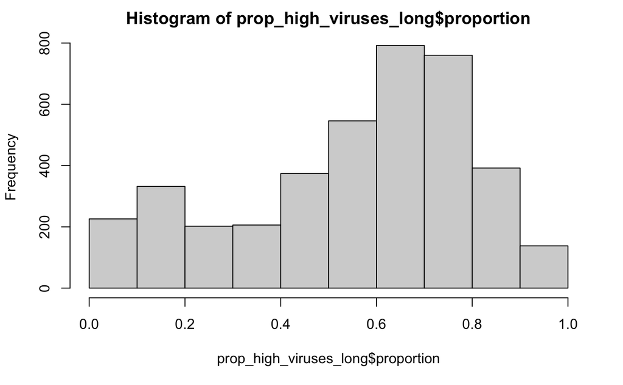

```r
hist(prop_high_viruses_long$proportion)
```

# numbers in common between two tool combos

```r
combos_list_two <- combos_list
combos_list_two$numtools <- str_count(combos_list_two$toolcombo, "1")
combos_list_two <- combos_list_two[combos_list_two$numtools==1,]

two_tool_pairs <- num_high_viruses[rownames(num_high_viruses) %in% combos_list_two$toolcombo,
                                   colnames(num_high_viruses) %in% combos_list_two$toolcombo]

colnames(two_tool_pairs) <- c("VS2", "VS", "VB", "tv", "DVF", "tnv")
rownames(two_tool_pairs) <- c("VS2", "VS", "VB", "tv", "DVF", "tnv")
```

```r
viral_scores_two <- viral_scores[,colnames(num_high_viruses) %in% combos_list_two$toolcombo]
n <- 6
viral_scores_two_comb <- matrix(data=NA, nrow=n, ncol=n)

for (i in 1:n) {
  for (j in 1:n) {
    if (i==j) {
      viral_scores_two_comb[i,j] <- sum(viral_scores_two[,i]>=1)
    }
    else if (i<j) {
      viral_scores_two_comb[i,j] <- sum((viral_scores_two[,i]+viral_scores_two[,j])>=1)
    }
    else if (i>j) {
      viral_scores_two_comb[i,j] <- paste(round(sum((viral_scores_two[,i]+viral_scores_two[,j])>=1)/sum(viral_scores_two[,i]>=1 | viral_scores_two[,j]>=1)*100, digits=0), "%", sep="")
    }
  }
}

colnames(viral_scores_two_comb) <- c("VS2", "VS", "VB", "tv", "DVF", "tnv")
rownames(viral_scores_two_comb) <- c("VS2", "VS", "VB", "tv", "DVF", "tnv")
```

```r
viral_scores_two_comb
```

```
    VS2     VS      VB      tv      DVF     tnv
VS2 "11754" "15381" "13705" "16610" "15433" "11076"
VS  "124%"  "2273"  "8666"  "14489" "7386"  "2266"
VB  "107%"  "118%"  "6383"  "11863" "11133" "6377"
tv  "113%"  "128%"  "101%"  "11166" "16707" "10755"
DVF "102%"  "107%"  "100%"  "111%"  "4820"  "2428"
tnv "94%"   "100%"  "100%"  "96%"   "50%"   "0"
```

comparing VS and VS2 viruses

```r
vs2_vs <- data.frame(vs2=viral_scores_two[,1],
```

[output not shown]

```r
                     vs=viral_scores_two[,2],
                     comb_score=viral_scores_two[,1]+viral_scores_two[,2],
                     seqtype=viruses$seqtype,
                     max_score_group=viruses$max_score_group)

vs2_vs$comb[vs2_vs$comb_score<1] <- "neither"
vs2_vs$comb[vs2_vs$vs2==0.5 & vs2_vs$vs==0.5] <- "both_low"
vs2_vs$comb[vs2_vs$vs2>=1 & vs2_vs$vs==0.5] <- "vs2_high_vs_low"
vs2_vs$comb[vs2_vs$vs2>=0.5 & vs2_vs$vs>=1] <- "vs2_low_vs_high"
vs2_vs$comb[vs2_vs$vs2>=1 & vs2_vs$vs==0] <- "vs2_only"
vs2_vs$comb[vs2_vs$vs2==0 & vs2_vs$vs>=1] <- "vs_only"
vs2_vs$comb[vs2_vs$vs2>=1 & vs2_vs$vs>=1] <- "both_high"

#vs2_vb$true_virus <- "not"
#vs2_vb$true_virus[vs2_vb$seqtype=="virus"] <- "virus"

vs2_vs_seqtype <- vs2_vs %>%
  group_by(comb, comb_score, seqtype) %>%
  summarise(n = n())
```

```r
table(vs2_vs$comb)
```

```
      both_high        both_low         neither         vs_only vs2_high_vs_low vs2_low_vs_high
           1645            2999           80910              25            7838             603
       vs2_only
           2271
```

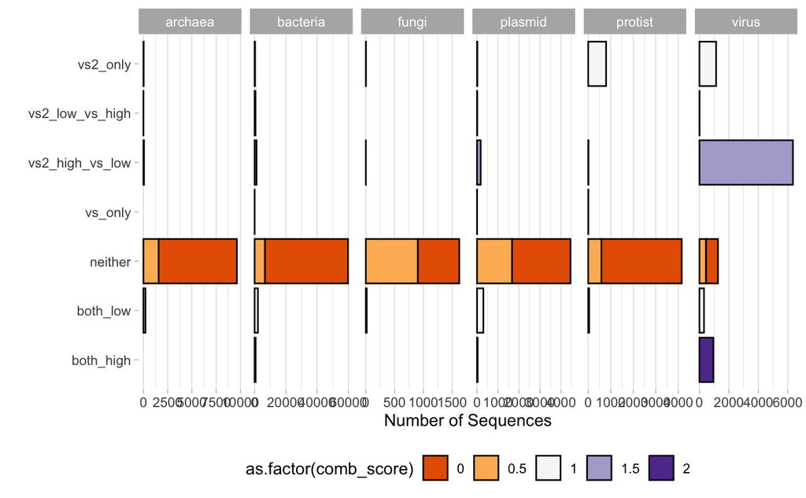

```r
ggplot(vs2_vs_seqtype, aes(y=n, x=comb,
                   fill=as.factor(comb_score))) +
  geom_bar(stat="identity", color="black") +
  theme_light() +
  coord_flip() +
  theme(
    panel.grid.major.y = element_blank(),
    panel.border = element_blank(),
    legend.position = "bottom"
  ) +
  scale_fill_brewer(palette = "PuOr", ) +
  xlab("") +
  ylab("Number of Sequences") +
  facet_grid(~seqtype, scales = "free")
```

comparing VS2 and VIBRANT viruses

```r
vs2_vb <- data.frame(vs2=viral_scores_two[,1],
                     vb=viral_scores_two[,3],
                     comb_score=viral_scores_two[,1]+viral_scores_two[,3],
                     seqtype=viruses$seqtype,
                     max_score_group=viruses$max_score_group)

vs2_vb$comb[vs2_vb$comb_score<1] <- "neither"
vs2_vb$comb[vs2_vb$vs2==0.5 & vs2_vb$vb==0.5] <- "both_low"
vs2_vb$comb[vs2_vb$vs2>=1 & vs2_vb$vb==0.5] <- "vs2_high_vb_low"
vs2_vb$comb[vs2_vb$vs2>=0.5 & vs2_vb$vb==1] <- "vs2_low_vb_high"
vs2_vb$comb[vs2_vb$vs2>=1 & vs2_vb$vb==0] <- "vs2_only"
vs2_vb$comb[vs2_vb$vs2==0 & vs2_vb$vb>=1] <- "vb_only"
vs2_vb$comb[vs2_vb$vs2>=1 & vs2_vb$vb>=1] <- "both_high"

#vs2_vb$true_virus <- "not"
#vs2_vb$true_virus[vs2_vb$seqtype=="virus"] <- "virus"

vs2_vb_seqtype <- vs2_vb %>%
  group_by(comb, comb_score, seqtype) %>%
  summarise(n = n())
```

```r
table(vs2_vb$comb)
```

```
      both_high        both_low         neither         vb_only vs2_high_vb_low vs2_low_vb_high
           5325             893           82586              47             285            1011
       vs2_only
           6144
```

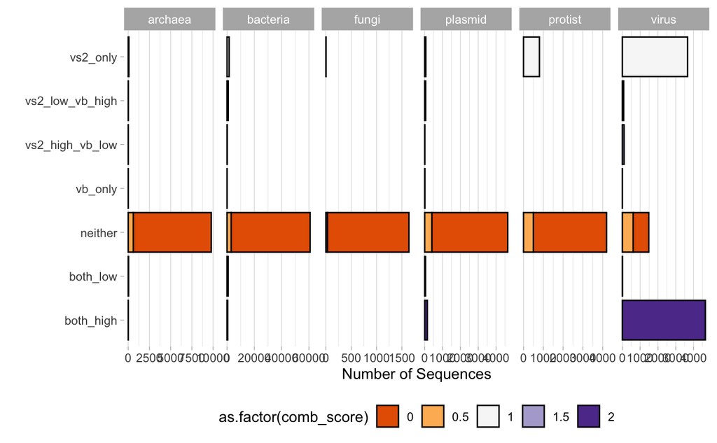

```r
ggplot(vs2_vb_seqtype, aes(y=n, x=comb,
                   fill=as.factor(comb_score))) +
  geom_bar(stat="identity", color="black") +
  theme_light() +
  coord_flip() +
  theme(
    panel.grid.major.y = element_blank(),
    panel.border = element_blank(),
    legend.position = "bottom"
  ) +
  scale_fill_brewer(palette = "PuOr", ) +
  xlab("") +
  ylab("Number of Sequences") +
  facet_grid(~seqtype, scales = "free")
```

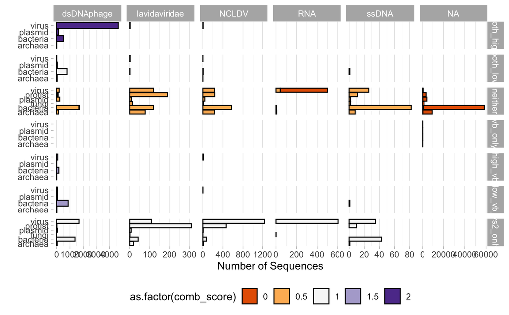

```r
ggplot(vs2_vb_seqtype, aes(y=n, x=seqtype,
                   fill=as.factor(comb_score))) +
  geom_bar(stat="identity", color="black") +
  theme_light() +
  coord_flip() +
  theme(
    panel.grid.major.y = element_blank(),
    panel.border = element_blank(),
    legend.position = "bottom"
  ) +
  scale_fill_brewer(palette = "PuOr", ) +
  xlab("") +
  ylab("Number of Sequences") +
  facet_grid(comb~max_score_group, scales = "free")
```

looking at the max_score_group

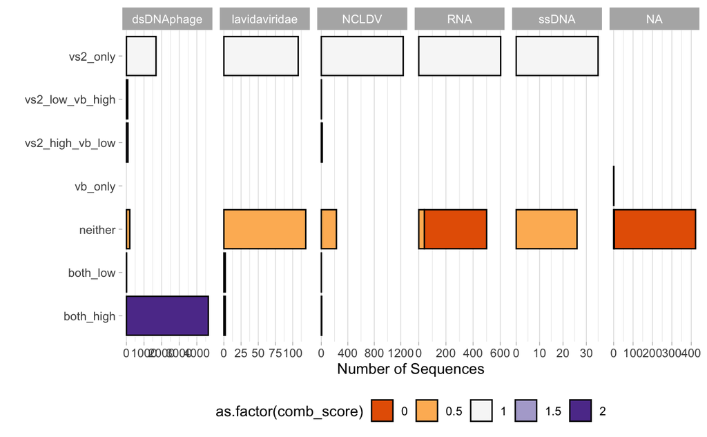

```r
ggplot(vs2_vb_seqtype[vs2_vb_seqtype$seqtype=="virus",], aes(y=n, x=comb,
                   fill=as.factor(comb_score))) +
  geom_bar(stat="identity", color="black") +
  theme_light() +
  coord_flip() +
  theme(
    panel.grid.major.y = element_blank(),
    panel.border = element_blank(),
    legend.position = "bottom"
  ) +
  scale_fill_brewer(palette = "PuOr", ) +
  xlab("") +
  ylab("Number of Sequences") +
  facet_grid(~max_score_group, scales = "free")
```

comparing VS2 and DVF viruses

```r
vs2_dvf <- data.frame(vs2=viral_scores_two[,1],
```

[output not shown]

```r
                     dvf=viral_scores_two[,5],
                     comb_score=viral_scores_two[,1]+viral_scores_two[,5],
                     seqtype=viruses$seqtype,
                     max_score_group=viruses$max_score_group)

vs2_dvf$comb[vs2_dvf$comb_score<1] <- "neither"
vs2_dvf$comb[vs2_dvf$vs2==0.5 & vs2_dvf$dvf==0.5] <- "both_low"
vs2_dvf$comb[vs2_dvf$vs2>=1 & vs2_dvf$dvf==0.5] <- "vs2_high_dvf_low"
vs2_dvf$comb[vs2_dvf$vs2>=0.5 & vs2_dvf$dvf==1] <- "vs2_low_dvf_high"
vs2_dvf$comb[vs2_dvf$vs2>=1 & vs2_dvf$dvf==0] <- "vs2_only"
vs2_dvf$comb[vs2_dvf$vs2==0 & vs2_dvf$dvf>=1] <- "dvf_only"
vs2_dvf$comb[vs2_dvf$vs2>=1 & vs2_dvf$dvf>=1] <- "both_high"

#vs2_vb$true_virus <- "not"
#vs2_vb$true_virus[vs2_vb$seqtype=="virus"] <- "virus"

vs2_dvf_seqtype <- vs2_dvf %>%
  group_by(comb, comb_score, seqtype, max_score_group) %>%
  summarise(n = n())
```

looking at the max_score_group

```r
ggplot(vs2_dvf_seqtype, aes(y=n, x=seqtype,
```

[output not shown]

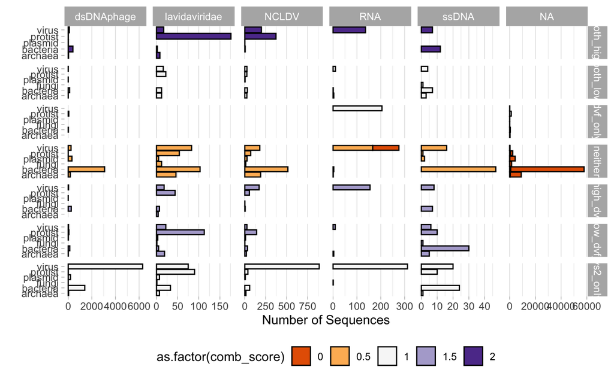

```r
                   fill=as.factor(comb_score))) +
  geom_bar(stat="identity", color="black") +
  theme_light() +
  coord_flip() +
  theme(
    panel.grid.major.y = element_blank(),
    panel.border = element_blank(),
    legend.position = "bottom"
  ) +
  scale_fill_brewer(palette = "PuOr", ) +
  xlab("") +
  ylab("Number of Sequences") +
  facet_grid(comb~max_score_group, scales = "free")
```

comparing VS2 and tv viruses

```r
vs2_tv <- data.frame(vs2=viral_scores_two[,1],
```

[output not shown]